# Analiza i modelowanie cen mieszkań w Polsce

Sylwester Sowula, Bartosz Opioła, Emanuel Sagan

2026-04-12

# 1. ANALIZA ROZKŁADÓW ZMIENNYCH

## 1a. Statystyki opisowe

```
##     cena_m2      wynagrodzenie     bezrobocie        ludnosc
##  Min.   : 1541   Min.   : 4669   Min.   : 1.000   Min.   :  18.80
##  1st Qu.: 4124   1st Qu.: 5412   1st Qu.: 4.400   1st Qu.:  52.11
##  Median : 4798   Median : 5671   Median : 6.450   Median :  74.22
##  Mean   : 4999   Mean   : 5820   Mean   : 7.293   Mean   :  99.75
##  3rd Qu.: 5502   3rd Qu.: 6027   3rd Qu.: 9.600   3rd Qu.: 109.06
##  Max.   :15079   Max.   :11362   Max.   :24.600   Max.   :1861.98
##     gestosc        urbanizacja     pozwolenia_na_1000 podmioty_gosp
##  Min.   :  18.2   Min.   :  1.10   Min.   :0.20       Min.   : 2.200
##  1st Qu.:  57.9   1st Qu.: 30.82   1st Qu.:1.70       1st Qu.: 4.600
##  Median :  89.8   Median : 44.85   Median :2.60       Median : 5.600
##  Mean   : 353.6   Mean   : 50.34   Mean   :2.75       Mean   : 5.945
##  3rd Qu.: 177.2   3rd Qu.: 63.23   3rd Qu.:3.50       3rd Qu.: 6.500
##  Max.   :3600.1   Max.   :100.00   Max.   :9.30       Max.   :17.600
##  studenci_na_1000  saldo_migracji_na_1000
##  Min.   :  0.000   Min.   :-9.4200
##  1st Qu.:  0.000   1st Qu.:-3.0625
##  Median :  0.000   Median :-1.7650
##  Mean   : 11.082   Mean   :-0.8943
##  3rd Qu.:  3.833   3rd Qu.: 0.1625
##  Max.   :186.780   Max.   :18.7800
```

```
##          cena_m2 wynagrodzenie bezrobocie ludnosc gestosc urbanizacja
## skosnosc   2.344         2.554      0.995   8.947   2.500       0.654
## kurtoza   13.245        15.490      3.978 113.991   8.947       2.491
##          pozwolenia_na_1000 podmioty_gosp studenci_na_1000
## skosnosc              0.942         1.815            3.781
## kurtoza               3.988         8.245           17.827
##          saldo_migracji_na_1000
## skosnosc                  1.810
## kurtoza                   7.499
```

**Wnioski ze statystyk opisowych:**

- **cena_m2**: mediana ~4 800 PLN, średnia ~5 000 PLN – lekka prawostronność (Warszawa, Kraków, Trójmiasto zawyżają średnią); rozstęp 1 541–15 079 PLN pokazuje ogromne zróżnicowanie regionalne.
- **wynagrodzenie**: mediana ~5 671 PLN, średnia ~5 820 PLN – umiarkowanie prawostronna; po usunięciu Jastrzębia-Zdroju ogon jest już znacznie mniejszy.
- **bezrobocie**: mediana ~6,5%, max ~24,6% – silna prawostronność; większość powiatów skupia się poniżej 10%, ale istnieje długi ogon powiatów strukturalnie bezrobotnych.
- **ludnosc**: mediana ~74 tys., max ~1 862 tys. (Warszawa) – klasyczny rozkład Pareto charakterystyczny dla systemów miejskich; ogromna asymetria.
- **gestosc**: mediana ~90 os/km², max ~3 600 os/km² – rozkład ekstremalnie prawostrony; centrum wielkich miast winduje maksimum.
- **urbanizacja**: zakres 1,1–100% przy medianie ~45% – stosunkowo symetryczny; wartości skrajne to powiaty czysto rolnicze vs. miasta na prawach powiatu.
- **pozwolenia_na_1000**: mediana ~2,6 – dane skupione blisko zera z długim ogonem; wyższe wartości odzwierciedlają aktywność budowlaną (więcej podaży).
- **podmioty_gosp**: mediana ~5,6 – zróżnicowanie umiarkowane; silniejsze prawostronne ogony w miastach z rozwiniętym sektorem usług.
- **studenci_na_1000**: mediana = 0 – ponad połowa powiatów nie posiada uczelni wyższej; rozkład silnie bimodalny: zero vs. wartości wysokie w powiatach akademickich.
- **saldo_migracji_na_1000**: mediana ~-1,8 – większość powiatów traci mieszkańców na rzecz miast; wartości dodatnie jedynie w strefach podmiejskich dużych aglomeracji (suburbanizacja).

## 1b. Histogramy zmiennych

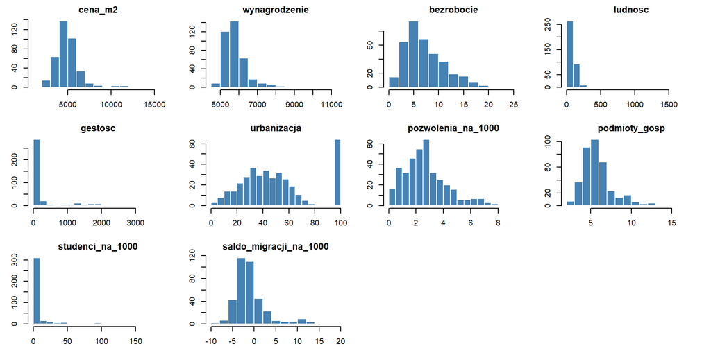

Histogramy potwierdzają wnioski ze statystyk opisowych: niemal wszystkie zmienne mają prawostronne ogony, a `studenci_na_1000` tworzy charakterystyczny rozkład z masą w zerze (brak uczelni) i oddzielnym skupiskiem dla powiatów akademickich.

## 1c. Wykresy pudełkowe zmiennych objaśniających (normalizacja Z dla porównywalności)

Standaryzacja (µ = 0, σ = 1) pozwala zestawić rozproszenie i asymetrię wszystkich zmiennych na jednej osi – bez niej różnice w skali (np. wynagrodzenie w PLN vs. bezrobocie w %) uniemożliwiałyby bezpośrednie porównanie.

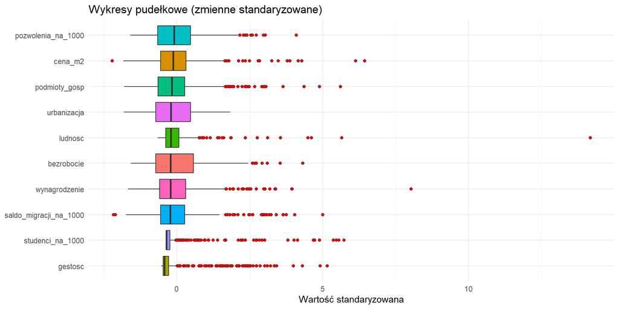

# 2. ANALIZA ZALEŻNOŚCI

## 2a. Wizualizacja macierzy korelacji

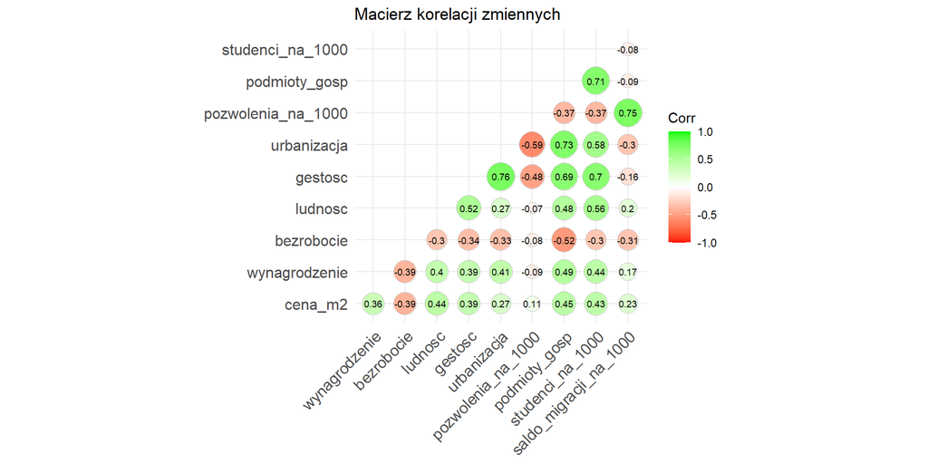

**Wnioski z korelacji z `cena_m2`:**

- **podmioty_gosp** (r = 0,45) i **ludnosc** (r = 0,44) – najsilniejszy związek dodatni; gęstość podmiotów gospodarczych jest proxy dla miejskiego charakteru powiatu i wysokiego popytu na mieszkania.
- **studenci_na_1000** (r = 0,43) – powiaty akademickie wykazują wyższą presję popytową i wyższe ceny.
- **bezrobocie** (r = -0,39) – istotna korelacja ujemna: wyższe bezrobocie to niższa siła nabywcza i słabszy popyt → niższe ceny.
- **wynagrodzenie** (r = 0,36) – umiarkowana korelacja dodatnia; zaskakująco niższa niż `podmioty_gosp`, co może wynikać z mniejszego zróżnicowania wynagrodzeń po usunięciu outliera (Jastrzębie-Zdrój).
- **gestosc** (r = 0,39) – gęstość zaludnienia silniej wiąże się z cenami niż sam wskaźnik urbanizacji (r = 0,27), bo lepiej oddaje intensywność zagospodarowania terenu.
- **pozwolenia_na_1000** (r = 0,11) – najsłabsza korelacja; pozwolenia budowlane reprezentują podaż, która może działać tłumiąco na ceny lub ujawniać się z opóźnieniem czasowym.

## 2b. Wykresy rozrzutu: zmienna objaśniana vs. predyktory

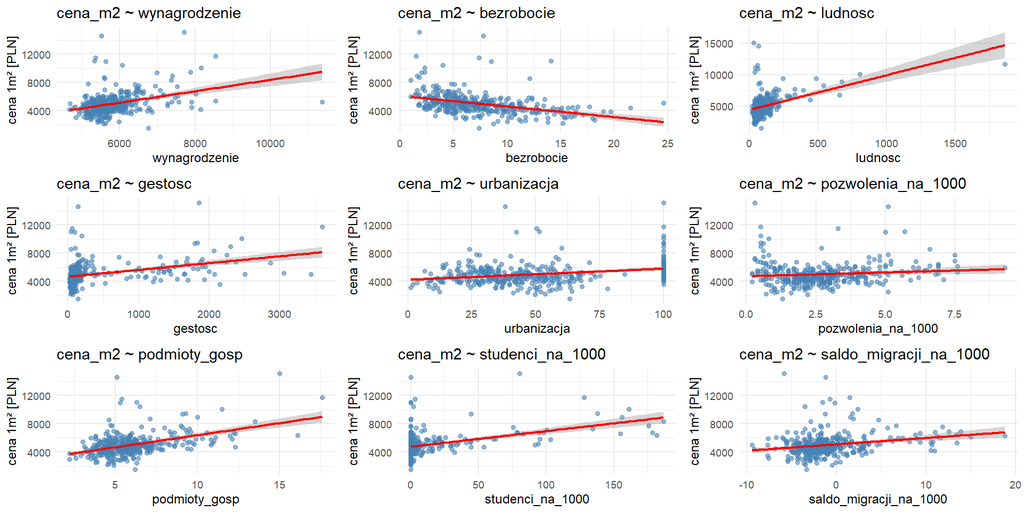

**Wnioski z wykresów rozrzutu:**

- **wynagrodzenie**: wyraźny trend wzrostowy, umiarkowany rozrzut; zależność w przybliżeniu liniowa.
- **bezrobocie**: trend malejący; przy wysokim bezrobociu ceny są jednorodnie niskie – sygnał heteroskedastyczności.
- **ludnosc** i **gestosc**: kilka obserwacji skrajnych silnie ciągnie linię regresji; chmura ma kształt wykładniczy, co sugeruje, że logarytmowanie zmiennej objaśnianej poprawi dopasowanie.
- **pozwolenia_na_1000**: niemal płaska linia regresji – spójne z niską korelacją (r = 0,11).
- **podmioty_gosp**: jedna z „czystszych” zależności liniowych w zbiorze – wyraźny trend, względnie mały rozrzut.
- **studenci_na_1000**: większość obserwacji skupiona przy x ≈ 0; powiaty akademickie wyraźnie wyżej, ale jest ich nielicznie.

# 3. PODZIAŁ NA ZBIÓR TRENINGOWY I TESTOWY

Podział losowy **70/30** (set.seed = 123 dla reprodukowalności). Przy ~370 obserwacjach po czyszczeniu zbiór treningowy (~260 obs.) jest wystarczający do estymacji modeli OLS z ~9 predyktorami (reguła co najmniej 10–20 obserwacji na zmienną), a zbiór testowy (~110 obs.) pozwala na wiarygodną ocenę zdolności predykcyjnych poza próbą (*out-of-sample validation*).

```r
set.seed(123)

n <- nrow(dane_clean)
indeksy_train <- sample(seq_len(n), size = floor(0.70 * n))  # 70% trening

zbior_train <- dane_clean[ indeksy_train, ]
zbior_test  <- dane_clean[-indeksy_train, ]

cat(sprintf("\nZbiór treningowy: %d obs. | Zbiór testowy: %d obs.\n",
            nrow(zbior_train), nrow(zbior_test)))
```

```
##
## Zbiór treningowy: 263 obs. | Zbiór testowy: 113 obs.
```

## 3a. Sprawdzenie czy rozkłady są zbliżone

```
## Średnia cena_m2 – trening: 4977.658
```

```
## Średnia cena_m2 – test:    5050.044
```

Zbliżone wartości średnich (różnica poniżej kilku procent) świadczą o losowości podziału i reprezentatywności obu podzbiorów – można przystąpić do estymacji modeli na zbiorze treningowym.

# 4. DOBÓR ZMIENNYCH I ESTYMACJA MODELI

## 4a. Model pełny (wszystkie zmienne)

```r
model_pelny <- lm(cena_m2 ~ wynagrodzenie + bezrobocie + ludnosc +
                    gestosc + urbanizacja + pozwolenia_na_1000 +
                    saldo_migracji_na_1000 + podmioty_gosp + studenci_na_1000,
                  data = zbior_train)
summary(model_pelny)
```

```
##
## Call:
## lm(formula = cena_m2 ~ wynagrodzenie + bezrobocie + ludnosc +
##     gestosc + urbanizacja + pozwolenia_na_1000 + saldo_migracji_na_1000 +
##     podmioty_gosp + studenci_na_1000, data = zbior_train)
##
## Residuals:
##     Min      1Q  Median      3Q     Max
## -3034.0  -628.6  -105.4   408.3  7521.4
##
## Coefficients:
##                         Estimate Std. Error t value Pr(>|t|)
## (Intercept)            1634.9743   885.0242   1.847 0.065860 .
## wynagrodzenie             0.1549     0.1247   1.243 0.215195
## bezrobocie              -28.1217    23.9392  -1.175 0.241214
## ludnosc                   1.5644     0.7616   2.054 0.040984 *
## gestosc                   0.3493     0.2492   1.401 0.162303
## urbanizacja               2.0391     5.5774   0.366 0.714968
## pozwolenia_na_1000      324.0990    90.2465   3.591 0.000395 ***
## saldo_migracji_na_1000  -13.1240    32.9825  -0.398 0.691032
## podmioty_gosp           213.2047    67.0402   3.180 0.001655 **
## studenci_na_1000          6.2640     3.9680   1.579 0.115670
## ---
## Signif. codes:  0 '***' 0.001 '**' 0.01 '*' 0.05 '.' 0.1 ' ' 1
##
## Residual standard error: 1206 on 253 degrees of freedom
## Multiple R-squared:  0.4276, Adjusted R-squared:  0.4072
## F-statistic:    21 on 9 and 253 DF,  p-value: < 2.2e-16
```

## 4b. Selekcja zmiennych metodą krokową (AIC)

Celem metody AIC (Akaike Information Criterion) jest znalezienie modelu wyjaśniającego największe zróżnicowanie danych, przy jednoczesnym karaniu modeli wykorzystujących nadmierną liczbę parametrów. Startując od pełnego modelu, algorytm stara się zminimalizować wartość AIC dodając lub usuwając kolejne zmienne objaśniające.
$$AIC = -2 \sum_{j} \ln(\hat{\pi}_j) + 2q,$$
gdzie:

$\hat{\pi}_j$ - estymowane prawdopodobieństwo, przy założeniach danego modelu, uzyskania takiej właśnie wartości obserwacji **j** jaka była naprawdę uzyskana,

q - liczba parametrów modelu.

```r
model_krokowy <- stepAIC(model_pelny,
                          direction = "both",
                          trace     = FALSE)
```

## 4c. Metoda Hellwiga

Podobnie jak AIC, metoda Hellwiga jest to metoda doboru zmiennych objaśniających do modelu ekonometrycznego. Metoda ta skupia się na znalezieniu silnej korelacji zmiennych objaśnianych ze zmienną objaśnianą oraz słabej korelacji pomiędzy zmiennymi objaśniającymi. Dodatkowo kieruje się integralnymi wskaźnikami pojemności informacyjnej **[`H`]** czyli sumą pojedyńczych pojemności **[`h`]** w każdej kombinacji, w tym wypadku jednak szukamy największej wartości.

$$h_{kj} = \frac{r_j^2}{1 + \sum_{l=1,l\neq j}^{m_k} |r_{lj}|}$$
gdzie:

k - numer kombinacji (k = 1, 2, …, $2^m$-1),

$m_k$ - liczba zmiennych w **k**-tej kombinacji,

j - numer zmiennej w rozpatrywanej kombinacji,

$r_j$ - współczynnik korelacji potencjalnej zmiennej objaśniającej o numerze j ze zmienną objaśnianą,

$r_{lj}$ - współczynnik korelacji między **l**-tą i **j**-tą potencjalną zmienną objaśniającą.

$$H_k = \sum_{j=1}^{m_k} h_{kj}$$
gdzie:

k - numer kombinacji,

$m_k$ - liczba zmiennych w **k**-tej kombinacji,

j - numer zmiennej w rozpatrywanej kombinacji.

```r
dane_Hellwig <- zbior_train[-c(1:2)]
cor_mat <- cor(dane_Hellwig)
r0 <-  cor_mat[1,-1]
r <- cor_mat[-1,-1]
comb <- expand.grid(rep(list(c(T,F)),ncol(r)))
H <- numeric(nrow(comb))

for(i in 1:nrow(comb)){

  k <- which(unlist(comb[i,]))

  if(length(k)==0){
    H[i] <- 0
  }else{
    h <- sapply(k,function(j){
      (r0[j]^2)/sum(abs(r[j,k]))
    })
    H[i] <- sum(h)
  }
}

max_H <- max(H)
best_model <- which.max(H)

best_vars <- names(r0)[which(unlist(comb[best_model,]))]

formula <- as.formula(
  paste("cena_m2 ~", paste(best_vars, collapse = " + "))
)

model_hellwig <- lm(formula, data = zbior_train)
```

# 5. DIAGNOSTYKA I PORÓWNANIE MODELI

## 5a. Funkcja wspomagająca diagnostykę

Funkcja pozwala zbadać między innymi: normalność reszt, heteroskedastycznośc, autokorelację oraz współliniowość.

```r
diagnostyka <- function(model){
  print(summary(model))
  print(shapiro.test(model$residuals))
  print(bptest(model))
  print(vif(model))
  print(dwtest(model))
  print(reset(model))
  print(runs.test(model$residuals))
}
```

## 5b. Diagnostyka modelu krokowego (AIC)

```r
diagnostyka(model_krokowy)
```

```
##
## Call:
## lm(formula = cena_m2 ~ wynagrodzenie + ludnosc + gestosc + pozwolenia_na_1000 +
##     podmioty_gosp + studenci_na_1000, data = zbior_train)
##
## Residuals:
##     Min      1Q  Median      3Q     Max
## -3028.2  -641.9  -102.1   431.1  7339.6
##
## Coefficients:
##                     Estimate Std. Error t value Pr(>|t|)
## (Intercept)        1187.4694   692.0346   1.716   0.0874 .
## wynagrodzenie         0.1812     0.1188   1.525   0.1284
## ludnosc               1.3990     0.6996   2.000   0.0466 *
## gestosc               0.4105     0.2195   1.870   0.0626 .
## pozwolenia_na_1000  310.2959    56.1719   5.524 8.14e-08 ***
## podmioty_gosp       253.9911    55.4003   4.585 7.12e-06 ***
## studenci_na_1000      5.5270     3.8965   1.418   0.1573
## ---
## Signif. codes:  0 '***' 0.001 '**' 0.01 '*' 0.05 '.' 0.1 ' ' 1
##
## Residual standard error: 1203 on 256 degrees of freedom
## Multiple R-squared:  0.424,  Adjusted R-squared:  0.4105
## F-statistic: 31.41 on 6 and 256 DF,  p-value: < 2.2e-16
##
##
##  Shapiro-Wilk normality test
##
## data:  model$residuals
## W = 0.79589, p-value < 2.2e-16
##
##
##  studentized Breusch-Pagan test
##
## data:  model
## BP = 16.899, df = 6, p-value = 0.009661
##
##      wynagrodzenie            ludnosc            gestosc pozwolenia_na_1000
##           1.343337           1.798666           3.446072           1.411472
##      podmioty_gosp   studenci_na_1000
##           2.613907           2.932815
##
##  Durbin-Watson test
##
## data:  model
## DW = 1.8515, p-value = 0.1149
## alternative hypothesis: true autocorrelation is greater than 0
##
##
##  RESET test
##
## data:  model
## RESET = 0.65293, df1 = 2, df2 = 254, p-value = 0.5214
##
##
##  Runs Test
##
## data:  model$residuals
## statistic = -2.1046, runs = 115, n1 = 131, n2 = 131, n = 262, p-value =
## 0.03533
## alternative hypothesis: nonrandomness
```

Zmienne wybrane przez algorytm: wynagrodzenie, ludność, gęstość, pozwolenia na 1000 osób, podmoty gospodarcze oraz studenci na 1000 osób. **$R^2$** na poziome 0.424 oznacza, że nasz model wyjaśnia 42,4% zmienności cen mieszkań za metr kwadratowy

Wykryte problemy:

- brak normalności reszt
- heteroskedastyczność
- brak losowości reszt

## 5c. Diagnostyka modelu Hellwiga

```r
diagnostyka(model_hellwig)
```

```
##
## Call:
## lm(formula = formula, data = zbior_train)
##
## Residuals:
##     Min      1Q  Median      3Q     Max
## -3327.5  -610.4  -145.3   450.8  7697.9
##
## Coefficients:
##                         Estimate Std. Error t value Pr(>|t|)
## (Intercept)            2886.7748   819.9329   3.521 0.000509 ***
## wynagrodzenie             0.1373     0.1245   1.103 0.271262
## bezrobocie              -31.1404    24.3598  -1.278 0.202283
## ludnosc                   1.6735     0.7075   2.365 0.018755 *
## podmioty_gosp           221.1233    59.6288   3.708 0.000256 ***
## studenci_na_1000          6.5581     3.6318   1.806 0.072131 .
## saldo_migracji_na_1000   69.7719    22.7725   3.064 0.002418 **
## ---
## Signif. codes:  0 '***' 0.001 '**' 0.01 '*' 0.05 '.' 0.1 ' ' 1
##
## Residual standard error: 1233 on 256 degrees of freedom
## Multiple R-squared:  0.3946, Adjusted R-squared:  0.3804
## F-statistic: 27.81 on 6 and 256 DF,  p-value: < 2.2e-16
##
##
##  Shapiro-Wilk normality test
##
## data:  model$residuals
## W = 0.78754, p-value < 2.2e-16
##
##
##  studentized Breusch-Pagan test
##
## data:  model
## BP = 17.786, df = 6, p-value = 0.006789
##
##          wynagrodzenie             bezrobocie                ludnosc
##               1.404127               1.694362               1.750007
##          podmioty_gosp       studenci_na_1000 saldo_migracji_na_1000
##               2.880751               2.423745               1.354643
##
##  Durbin-Watson test
##
## data:  model
## DW = 1.8435, p-value = 0.1029
## alternative hypothesis: true autocorrelation is greater than 0
##
##
##  RESET test
##
## data:  model
## RESET = 0.42057, df1 = 2, df2 = 254, p-value = 0.6571
##
##
##  Runs Test
##
## data:  model$residuals
## statistic = -1.9808, runs = 116, n1 = 131, n2 = 131, n = 262, p-value =
## 0.04762
## alternative hypothesis: nonrandomness
```

Zmienne wybrane przez algorytm: wynagrodzenie, bezrobocie, ludność, saldo migracji na 1000 osób, podmioty gospodarcze oraz studenci na 1000 osób. **$R^2$** jest równe 0.3946 co oznacza, że model wyjaśnia 39,46% zmienności cen mieszkań za metr kwadratowy. Jest to nieco mniej niż w przypadku modelu krokowego.

Wykryte problemy:

- brak normalności reszt
- heteroskedastyczność
- brak losowości reszt

## 5d. Diagnostyka modelu krokowego (AIC) ze zlogarytmizowaną zmienną objaśnianą

```r
model_krokowy_log <- update(model_krokowy, log(cena_m2) ~ .)
diagnostyka(model_krokowy_log)
```

```
##
## Call:
## lm(formula = log(cena_m2) ~ wynagrodzenie + ludnosc + gestosc +
##     pozwolenia_na_1000 + podmioty_gosp + studenci_na_1000, data = zbior_train)
##
## Residuals:
##      Min       1Q   Median       3Q      Max
## -1.03030 -0.11832  0.00076  0.11317  0.94129
##
## Coefficients:
##                     Estimate Std. Error t value Pr(>|t|)
## (Intercept)        7.806e+00  1.256e-01  62.165  < 2e-16 ***
## wynagrodzenie      2.624e-05  2.155e-05   1.218   0.2244
## ludnosc            1.291e-04  1.269e-04   1.017   0.3099
## gestosc            9.800e-05  3.983e-05   2.460   0.0145 *
## pozwolenia_na_1000 6.845e-02  1.019e-02   6.716 1.20e-10 ***
## podmioty_gosp      4.408e-02  1.005e-02   4.385 1.69e-05 ***
## studenci_na_1000   1.026e-03  7.070e-04   1.451   0.1480
## ---
## Signif. codes:  0 '***' 0.001 '**' 0.01 '*' 0.05 '.' 0.1 ' ' 1
##
## Residual standard error: 0.2182 on 256 degrees of freedom
## Multiple R-squared:  0.4084, Adjusted R-squared:  0.3945
## F-statistic: 29.45 on 6 and 256 DF,  p-value: < 2.2e-16
##
##
##  Shapiro-Wilk normality test
##
## data:  model$residuals
## W = 0.94122, p-value = 9.333e-09
##
##
##  studentized Breusch-Pagan test
##
## data:  model
## BP = 5.5428, df = 6, p-value = 0.4763
##
##      wynagrodzenie            ludnosc            gestosc pozwolenia_na_1000
##           1.343337           1.798666           3.446072           1.411472
##      podmioty_gosp   studenci_na_1000
##           2.613907           2.932815
##
##  Durbin-Watson test
##
## data:  model
## DW = 1.8649, p-value = 0.1375
## alternative hypothesis: true autocorrelation is greater than 0
##
##
##  RESET test
##
## data:  model
## RESET = 2.4322, df1 = 2, df2 = 254, p-value = 0.08989
##
##
##  Runs Test
##
## data:  model$residuals
## statistic = -2.1046, runs = 115, n1 = 131, n2 = 131, n = 262, p-value =
## 0.03533
## alternative hypothesis: nonrandomness
```

Tym sposobem pozbyliśmy się heteroskedastyczności, jednakże reszta problemów pozostaje nierozwiązana. **$R^2$** wynosi 40,84%.

Warto również zauważyć, iż 3 zmienne mają p-value > 0.05. Co ważne, nie zostaną one usunięte ponieważ Metoda krokowa AIC celowo nie kieruje się istotnością statystyczną, tylko kryterium informacyjnym. AIC może zachować zmienną z p-value > 0,05 jeśli jej obecność obniża AIC, bo nawet słaby predyktor może poprawiać globalne dopasowanie modelu.

## 5e. Diagnostyka modelu Hellwiga ze zlogarytmizowaną zmienną objaśnianą

```r
model_hellwig_log <- update(model_hellwig, log(cena_m2) ~ .)
diagnostyka(model_hellwig_log)
```

```
##
## Call:
## lm(formula = log(cena_m2) ~ wynagrodzenie + bezrobocie + ludnosc +
##     podmioty_gosp + studenci_na_1000 + saldo_migracji_na_1000,
##     data = zbior_train)
##
## Residuals:
##      Min       1Q   Median       3Q      Max
## -1.09305 -0.10512 -0.00028  0.10631  0.94641
##
## Coefficients:
##                          Estimate Std. Error t value Pr(>|t|)
## (Intercept)             8.251e+00  1.488e-01  55.456  < 2e-16 ***
## wynagrodzenie           1.289e-05  2.259e-05   0.571 0.568773
## bezrobocie             -1.077e-02  4.420e-03  -2.437 0.015508 *
## ludnosc                 1.925e-04  1.284e-04   1.499 0.134989
## podmioty_gosp           3.353e-02  1.082e-02   3.099 0.002158 **
## studenci_na_1000        1.393e-03  6.590e-04   2.114 0.035507 *
## saldo_migracji_na_1000  1.495e-02  4.132e-03   3.619 0.000357 ***
## ---
## Signif. codes:  0 '***' 0.001 '**' 0.01 '*' 0.05 '.' 0.1 ' ' 1
##
## Residual standard error: 0.2238 on 256 degrees of freedom
## Multiple R-squared:  0.378,  Adjusted R-squared:  0.3634
## F-statistic: 25.93 on 6 and 256 DF,  p-value: < 2.2e-16
##
##
##  Shapiro-Wilk normality test
##
## data:  model$residuals
## W = 0.92738, p-value = 4.762e-10
##
##
##  studentized Breusch-Pagan test
##
## data:  model
## BP = 7.0329, df = 6, p-value = 0.3178
##
##          wynagrodzenie             bezrobocie                ludnosc
##               1.404127               1.694362               1.750007
##          podmioty_gosp       studenci_na_1000 saldo_migracji_na_1000
##               2.880751               2.423745               1.354643
##
##  Durbin-Watson test
##
## data:  model
## DW = 1.8115, p-value = 0.06346
## alternative hypothesis: true autocorrelation is greater than 0
##
##
##  RESET test
##
## data:  model
## RESET = 2.1216, df1 = 2, df2 = 254, p-value = 0.122
##
##
##  Runs Test
##
## data:  model$residuals
## statistic = -1.7332, runs = 118, n1 = 131, n2 = 131, n = 262, p-value =
## 0.08307
## alternative hypothesis: nonrandomness
```

Zlogarytmizowany model Hellwiga pozbył się heteroskedastyczności oraz przeszedł pozytywnie test serii (test losowości reszt). **$R^2$** wynosi 37,8%.

Tutaj sytuacja jest podobna, albowiem znowu widzimy zmienne, które są statystyczne nieistotne i tutaj również nie zostaną one usunięte z modelu, ponieważ dzięki tym zmiennym został zmaksymalizowany wskaźnik H podczas doboru parametrów.

# 6. PREDYKCJA NA ZBIORZE TESTOWYM ORAZ PORÓWNANIE MODELI

## 6a. Predykcja oraz liczenie błędów ex post

```r
p1_log <- predict(model_krokowy_log, newdata = zbior_test)
pred1  <- exp(p1_log)

p2_log <- predict(model_hellwig_log, newdata = zbior_test)
pred2  <- exp(p2_log)

e1 <- zbior_test$cena_m2 - pred1
e2 <- zbior_test$cena_m2 - pred2

MAE1 <- mean(abs(e1))
MAE2 <- mean(abs(e2))

RMSE1 <- sqrt(mean(e1^2))
RMSE2 <- sqrt(mean(e2^2))

MAPE1 <- mean(abs(e1 / zbior_test$cena_m2)) * 100
MAPE2 <- mean(abs(e2 / zbior_test$cena_m2)) * 100

wyniki_porownanie <- data.frame(
  Model = c("AIC (log)", "Hellwig (log)"),
  MAE   = round(c(MAE1, MAE2), 2),
  RMSE  = round(c(RMSE1, RMSE2), 2),
  MAPE  = round(c(MAPE1, MAPE2), 2)
)
```

## 6b. Prezentacja wyników

| Model | MAE | RMSE | MAPE |
| --- | --- | --- | --- |
| AIC (log) | 826.26 | 1371.64 | 15.82 |
| Hellwig (log) | 840.60 | 1433.92 | 16.04 |

Na podstawie powyższych wyników możemy stwierdzić, iż model krokowy (AIC) popełnia mniejsze błedy podczas predykcji.

**MAE** na poziomie 826,26 oznacza, że model myli się średnio o właśnie tyle złotych. Większa wartość RMSE może wskazywać na pojawiające się w zbiorze danych wartości odstające. Dodatkowo, dzięki MAPE wiemy, że nasz model myli się średnio o 15,82%.

## 6c. Analiza i wizualizacja wyników

## Wartości rzeczywiste vs przewidywane

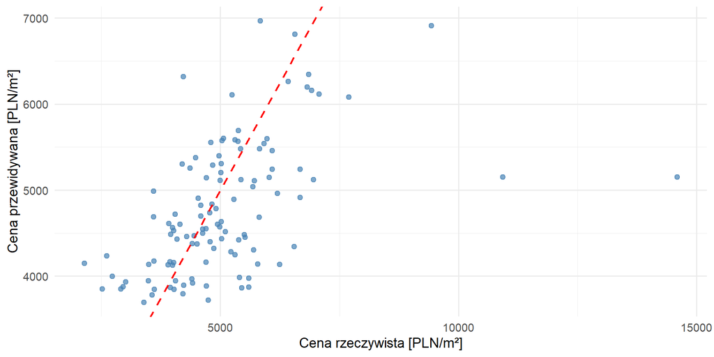

Wykres przedstawia relację między rzeczywistymi cenami transakcyjnymi na metrze kwadratowym (oś X) a cenami przewidzianymi przez model(oś Y). Czerwona, przerywana linia reprezentuje predykcję idealną $y=x$.

Dla większości powiatów, gdzie ceny rzeczywiste mieszczą się w przedziale 4000 – 7000 PLN/$m^2$, punkty rozmieszczone są blisko prostej $y=x$, co oznacza, że model radzi sobie dobrze jeśli chodzi o typowe nieruchomości.

Widoczny jest również istotny problem z niedoszacowaniem cen w najdroższych powiatach (ceny rzeczywiste > 8000 PLN/$m^2$). Punkty te znajdują się wyraźnie poniżej czerwonej linii. Największy błąd predykcji występuje dla powiatu o cenie rzeczywistej blisko 15 000 PLN/$m^2$, który model wycenił na jedynie ok. 5200 PLN/$m^2$.

## Top i Bottom 10 powiatów pod względem procentowego błędu predykcji

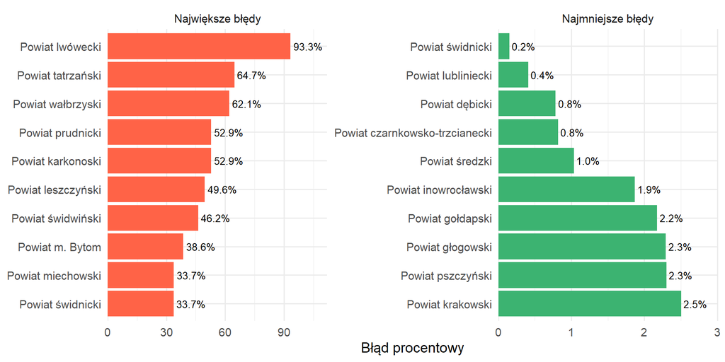

Największy błąd procentowy miał miejsce dla powiatu iwóweckiego (woj. dolnośląskie) i wynosi 93,3%, natomiast model najlepiej poradził sobię z powiatem świdnickim (woj. dolnośląskie) oraz z powiatem lublinieckim (woj. śląskie) gdzie procentowy błąd wyniósł kolejno 0,2% oraz 0,4%

## Top i Bottom 10 powiatów pod względem błędu predykcji w PLN

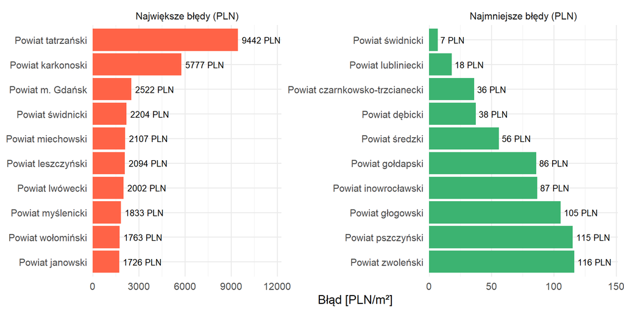

Jeśli chodzi o pomyłkę w PLN, to miejsce pierwsze zajmuje powiat tatrzański, gdzie pomyłka ta wyniosła 9442 zł. Widzimy to również na pierwszym wykresie, gdzie punkt reprezentujący powiat tatrzański znajduję się najbardziej na prawo. Najmniejszy błąd w PLN możemy zauważyć w powiecie świdnickim, co pokrywa się z poprzednim wykresem, gdzie ten sam powiat miał najmnieszy błąd procentowy.